# 目录

```python
import pandas as pd
import numpy as np
```

```python
'''设置一个shell的多结果输出'''
from IPython.core.interactiveshell import InteractiveShell
InteractiveShell.ast_node_interactivity = 'all'
```

# 数据的聚合操作

## 聚合

- grouped.mean().count().max()
  - 或者自定义函数
- grouped.agg([函数方法（聚合操作）])
- grouped.agg([('play','mean'),('yeah',func)])
- grouped.agg({'column_name':'mean','column_name2':[方法]})
- df.groupby('key1',as_index=False).agg()
  - 或者df.groupby('key1').agg().reset_index()

```python
df = pd.DataFrame({'key1' : ['a', 'a', 'b', 'b', 'a'],
                   'key2' : ['one', 'two', 'one', 'two', 'one'],
                   'data1' : np.random.randn(5),
                   'data2' : np.random.randn(5)})
df
```

|  | key1 | key2 | data1 | data2 |
| --- | --- | --- | --- | --- |
| 0 | a | one | -0.859262 | -1.160968 |
| 1 | a | two | 0.452417 | 0.667774 |
| 2 | b | one | -0.772293 | 1.199919 |
| 3 | b | two | 0.518282 | 0.638369 |
| 4 | a | one | 0.250509 | -2.431030 |

```python
grouped = df.groupby('key1')
grouped['data1'].quantile(0.9)
```

```
key1
a    0.412035
b    0.389224
Name: data1, dtype: float64
```

```python
'''自定义函数进行汇总'''
def peak_to_peak(arr):
    return arr.max() - arr.min()

grouped.agg(peak_to_peak)
```

```
'自定义函数进行汇总'
```

| key1 | data1 | data2 |
| --- | --- | --- |
| a | 1.311679 | 3.098804 |
| b | 1.290575 | 0.561549 |

```python
grouped['data1'].describe() #甚至可以这样
```

| key1 | count | mean | std | min | 25% | 50% | 75% | max |
| --- | --- | --- | --- | --- | --- | --- | --- | --- |
| a | 3.0 | -0.052112 | 0.706265 | -0.859262 | -0.304376 | 0.250509 | 0.351463 | 0.452417 |
| b | 2.0 | -0.127006 | 0.912574 | -0.772293 | -0.449650 | -0.127006 | 0.195638 | 0.518282 |

```python
tips = pd.read_csv('examples/tips.csv')
tips['tip_pct'] = tips['tip'] / tips['total_bill']
tips.head()
```

|  | total_bill | tip | smoker | day | time | size | tip_pct |
| --- | --- | --- | --- | --- | --- | --- | --- |
| 0 | 16.99 | 1.01 | No | Sun | Dinner | 2 | 0.059447 |
| 1 | 10.34 | 1.66 | No | Sun | Dinner | 3 | 0.160542 |
| 2 | 21.01 | 3.50 | No | Sun | Dinner | 3 | 0.166587 |
| 3 | 23.68 | 3.31 | No | Sun | Dinner | 2 | 0.139780 |
| 4 | 24.59 | 3.61 | No | Sun | Dinner | 4 | 0.146808 |

```python
grouped = tips.groupby(['day', 'smoker'])
grouped_pct = grouped['tip_pct']
grouped_pct.agg('mean')
```

```
day   smoker
Fri   No        0.151650
      Yes       0.174783
Sat   No        0.158048
      Yes       0.147906
Sun   No        0.160113
      Yes       0.187250
Thur  No        0.160298
      Yes       0.163863
Name: tip_pct, dtype: float64
```

```python
'''使用列表传入多个方法'''
grouped_pct.agg(['mean', 'std', peak_to_peak])
```

| day | smoker | mean | std | peak_to_peak |
| --- | --- | --- | --- | --- |
| Fri | No | 0.151650 | 0.028123 | 0.067349 |
|  | Yes | 0.174783 | 0.051293 | 0.159925 |
| Sat | No | 0.158048 | 0.039767 | 0.235193 |
|  | Yes | 0.147906 | 0.061375 | 0.290095 |
| Sun | No | 0.160113 | 0.042347 | 0.193226 |
|  | Yes | 0.187250 | 0.154134 | 0.644685 |
| Thur | No | 0.160298 | 0.038774 | 0.193350 |
|  | Yes | 0.163863 | 0.039389 | 0.151240 |

```python
'''为使用的方法重命名显示'''
grouped_pct.agg([('foo', 'mean'), ('bar', np.std)])
```

| day | smoker | foo | bar |
| --- | --- | --- | --- |
| Fri | No | 0.151650 | 0.028123 |
|  | Yes | 0.174783 | 0.051293 |
| Sat | No | 0.158048 | 0.039767 |
|  | Yes | 0.147906 | 0.061375 |
| Sun | No | 0.160113 | 0.042347 |
|  | Yes | 0.187250 | 0.154134 |
| Thur | No | 0.160298 | 0.038774 |
|  | Yes | 0.163863 | 0.039389 |

```python
functions = ['count', 'mean', 'max']
grouped['tip_pct','total_bill'].agg(functions)
```

| day | smoker | tip_pct count | tip_pct mean | tip_pct max | total_bill count | total_bill mean | total_bill max |
| --- | --- | --- | --- | --- | --- | --- | --- |
| Fri | No | 4 | 0.151650 | 0.187735 | 4 | 18.420000 | 22.75 |
|  | Yes | 15 | 0.174783 | 0.263480 | 15 | 16.813333 | 40.17 |
| Sat | No | 45 | 0.158048 | 0.291990 | 45 | 19.661778 | 48.33 |
|  | Yes | 42 | 0.147906 | 0.325733 | 42 | 21.276667 | 50.81 |
| Sun | No | 57 | 0.160113 | 0.252672 | 57 | 20.506667 | 48.17 |
|  | Yes | 19 | 0.187250 | 0.710345 | 19 | 24.120000 | 45.35 |
| Thur | No | 45 | 0.160298 | 0.266312 | 45 | 17.113111 | 41.19 |
|  | Yes | 17 | 0.163863 | 0.241255 | 17 | 19.190588 | 43.11 |

```python
ftuples = [('Durchschnitt', 'mean'), ('Abweichung', np.var)]
grouped['tip_pct', 'total_bill'].agg(ftuples)
```

| day | smoker | tip_pct Durchschnitt | tip_pct Abweichung | total_bill Durchschnitt | total_bill Abweichung |
| --- | --- | --- | --- | --- | --- |
| Fri | No | 0.151650 | 0.000791 | 18.420000 | 25.596333 |
|  | Yes | 0.174783 | 0.002631 | 16.813333 | 82.562438 |
| Sat | No | 0.158048 | 0.001581 | 19.661778 | 79.908965 |
|  | Yes | 0.147906 | 0.003767 | 21.276667 | 101.387535 |
| Sun | No | 0.160113 | 0.001793 | 20.506667 | 66.099980 |
|  | Yes | 0.187250 | 0.023757 | 24.120000 | 109.046044 |
| Thur | No | 0.160298 | 0.001503 | 17.113111 | 59.625081 |
|  | Yes | 0.163863 | 0.001551 | 19.190588 | 69.808518 |

```python
'''不同列使用不同的函数'''
grouped.agg({'tip' : np.max, 'size' : 'sum'})
```

| day | smoker | tip | size |
| --- | --- | --- | --- |
| Fri | No | 3.50 | 9 |
|  | Yes | 4.73 | 31 |
| Sat | No | 9.00 | 115 |
|  | Yes | 10.00 | 104 |
| Sun | No | 6.00 | 167 |
|  | Yes | 6.50 | 49 |
| Thur | No | 6.70 | 112 |
|  | Yes | 5.00 | 40 |

```python
grouped.agg({'tip_pct' : ['min', 'max', 'mean', 'std'],
             'size' : 'sum'})
```

| day | smoker | tip_pct min | tip_pct max | tip_pct mean | tip_pct std | size sum |
| --- | --- | --- | --- | --- | --- | --- |
| Fri | No | 0.120385 | 0.187735 | 0.151650 | 0.028123 | 9 |
|  | Yes | 0.103555 | 0.263480 | 0.174783 | 0.051293 | 31 |
| Sat | No | 0.056797 | 0.291990 | 0.158048 | 0.039767 | 115 |
|  | Yes | 0.035638 | 0.325733 | 0.147906 | 0.061375 | 104 |
| Sun | No | 0.059447 | 0.252672 | 0.160113 | 0.042347 | 167 |
|  | Yes | 0.065660 | 0.710345 | 0.187250 | 0.154134 | 49 |
| Thur | No | 0.072961 | 0.266312 | 0.160298 | 0.038774 | 112 |
|  | Yes | 0.090014 | 0.241255 | 0.163863 | 0.039389 | 40 |

```python
'''重置index'''
grouped = tips.groupby(['day', 'smoker'])
grouped.agg({'tip_pct' : ['min', 'max', 'mean', 'std'],
             'size' : 'sum'}).reset_index()

grouped = tips.groupby(['day', 'smoker'],as_index=False)
grouped.agg({'tip_pct' : ['min', 'max', 'mean', 'std'],
             'size' : 'sum'})
```

```
'重置index'
```

|  | day | smoker | tip_pct min | tip_pct max | tip_pct mean | tip_pct std | size sum |
| --- | --- | --- | --- | --- | --- | --- | --- |
| 0 | Fri | No | 0.120385 | 0.187735 | 0.151650 | 0.028123 | 9 |
| 1 | Fri | Yes | 0.103555 | 0.263480 | 0.174783 | 0.051293 | 31 |
| 2 | Sat | No | 0.056797 | 0.291990 | 0.158048 | 0.039767 | 115 |
| 3 | Sat | Yes | 0.035638 | 0.325733 | 0.147906 | 0.061375 | 104 |
| 4 | Sun | No | 0.059447 | 0.252672 | 0.160113 | 0.042347 | 167 |
| 5 | Sun | Yes | 0.065660 | 0.710345 | 0.187250 | 0.154134 | 49 |
| 6 | Thur | No | 0.072961 | 0.266312 | 0.160298 | 0.038774 | 112 |
| 7 | Thur | Yes | 0.090014 | 0.241255 | 0.163863 | 0.039389 | 40 |

|  | day | smoker | tip_pct min | tip_pct max | tip_pct mean | tip_pct std | size sum |
| --- | --- | --- | --- | --- | --- | --- | --- |
| 0 | Fri | No | 0.120385 | 0.187735 | 0.151650 | 0.028123 | 9 |
| 1 | Fri | Yes | 0.103555 | 0.263480 | 0.174783 | 0.051293 | 31 |
| 2 | Sat | No | 0.056797 | 0.291990 | 0.158048 | 0.039767 | 115 |
| 3 | Sat | Yes | 0.035638 | 0.325733 | 0.147906 | 0.061375 | 104 |
| 4 | Sun | No | 0.059447 | 0.252672 | 0.160113 | 0.042347 | 167 |
| 5 | Sun | Yes | 0.065660 | 0.710345 | 0.187250 | 0.154134 | 49 |
| 6 | Thur | No | 0.072961 | 0.266312 | 0.160298 | 0.038774 | 112 |
| 7 | Thur | Yes | 0.090014 | 0.241255 | 0.163863 | 0.039389 | 40 |

## apply:另一种聚合操作

- np.average(data,weights=)进行加权平均
- 对每个group实行apply中的操作之后再将它们合起来
- df.groupby('key',group_keys=False).sum()不显示组的名称
- group.name可以调用组名称然后针对组名称实行不同的操作
- pd.read_csv('examples/stock_px_2.csv', parse_dates=True,index_col=0)parse_dates=True将字符型数据转化为日期型
- data.pct.change()计算百分比变化率

```python
tips = pd.read_csv('examples/tips.csv')
tips['tip_pct'] = tips['tip'] / tips['total_bill']
tips.head()
```

|  | total_bill | tip | smoker | day | time | size | tip_pct |
| --- | --- | --- | --- | --- | --- | --- | --- |
| 0 | 16.99 | 1.01 | No | Sun | Dinner | 2 | 0.059447 |
| 1 | 10.34 | 1.66 | No | Sun | Dinner | 3 | 0.160542 |
| 2 | 21.01 | 3.50 | No | Sun | Dinner | 3 | 0.166587 |
| 3 | 23.68 | 3.31 | No | Sun | Dinner | 2 | 0.139780 |
| 4 | 24.59 | 3.61 | No | Sun | Dinner | 4 | 0.146808 |

```python
def top(df,n=5,column='tip_pct'):
    return df.sort_values(by=column)[-n:]

top(tips,n=6)
```

|  | total_bill | tip | smoker | day | time | size | tip_pct |
| --- | --- | --- | --- | --- | --- | --- | --- |
| 109 | 14.31 | 4.00 | Yes | Sat | Dinner | 2 | 0.279525 |
| 183 | 23.17 | 6.50 | Yes | Sun | Dinner | 4 | 0.280535 |
| 232 | 11.61 | 3.39 | No | Sat | Dinner | 2 | 0.291990 |
| 67 | 3.07 | 1.00 | Yes | Sat | Dinner | 1 | 0.325733 |
| 178 | 9.60 | 4.00 | Yes | Sun | Dinner | 2 | 0.416667 |
| 172 | 7.25 | 5.15 | Yes | Sun | Dinner | 2 | 0.710345 |

```python
#分组进行排序
tips.groupby('smoker').apply(top)
```

| smoker |  | total_bill | tip | smoker | day | time | size | tip_pct |
| --- | --- | --- | --- | --- | --- | --- | --- | --- |
| No | 88 | 24.71 | 5.85 | No | Thur | Lunch | 2 | 0.236746 |
|  | 185 | 20.69 | 5.00 | No | Sun | Dinner | 5 | 0.241663 |
|  | 51 | 10.29 | 2.60 | No | Sun | Dinner | 2 | 0.252672 |
|  | 149 | 7.51 | 2.00 | No | Thur | Lunch | 2 | 0.266312 |
|  | 232 | 11.61 | 3.39 | No | Sat | Dinner | 2 | 0.291990 |
| Yes | 109 | 14.31 | 4.00 | Yes | Sat | Dinner | 2 | 0.279525 |
|  | 183 | 23.17 | 6.50 | Yes | Sun | Dinner | 4 | 0.280535 |
|  | 67 | 3.07 | 1.00 | Yes | Sat | Dinner | 1 | 0.325733 |
|  | 178 | 9.60 | 4.00 | Yes | Sun | Dinner | 2 | 0.416667 |
|  | 172 | 7.25 | 5.15 | Yes | Sun | Dinner | 2 | 0.710345 |

```python
tips.groupby('smoker').apply(top,n=6,column='size')
```

| smoker |  | total_bill | tip | smoker | day | time | size | tip_pct |
| --- | --- | --- | --- | --- | --- | --- | --- | --- |
| No | 142 | 41.19 | 5.00 | No | Thur | Lunch | 5 | 0.121389 |
|  | 155 | 29.85 | 5.14 | No | Sun | Dinner | 5 | 0.172194 |
|  | 143 | 27.05 | 5.00 | No | Thur | Lunch | 6 | 0.184843 |
|  | 141 | 34.30 | 6.70 | No | Thur | Lunch | 6 | 0.195335 |
|  | 156 | 48.17 | 5.00 | No | Sun | Dinner | 6 | 0.103799 |
|  | 125 | 29.80 | 4.20 | No | Thur | Lunch | 6 | 0.140940 |
| Yes | 183 | 23.17 | 6.50 | Yes | Sun | Dinner | 4 | 0.280535 |
|  | 180 | 34.65 | 3.68 | Yes | Sun | Dinner | 4 | 0.106205 |
|  | 219 | 30.14 | 3.09 | Yes | Sat | Dinner | 4 | 0.102522 |
|  | 56 | 38.01 | 3.00 | Yes | Sat | Dinner | 4 | 0.078927 |
|  | 216 | 28.15 | 3.00 | Yes | Sat | Dinner | 5 | 0.106572 |
|  | 187 | 30.46 | 2.00 | Yes | Sun | Dinner | 5 | 0.065660 |

```python
tips.groupby('smoker', group_keys=False).apply(top)
```

|  | total_bill | tip | smoker | day | time | size | tip_pct |
| --- | --- | --- | --- | --- | --- | --- | --- |
| 88 | 24.71 | 5.85 | No | Thur | Lunch | 2 | 0.236746 |
| 185 | 20.69 | 5.00 | No | Sun | Dinner | 5 | 0.241663 |
| 51 | 10.29 | 2.60 | No | Sun | Dinner | 2 | 0.252672 |
| 149 | 7.51 | 2.00 | No | Thur | Lunch | 2 | 0.266312 |
| 232 | 11.61 | 3.39 | No | Sat | Dinner | 2 | 0.291990 |
| 109 | 14.31 | 4.00 | Yes | Sat | Dinner | 2 | 0.279525 |
| 183 | 23.17 | 6.50 | Yes | Sun | Dinner | 4 | 0.280535 |
| 67 | 3.07 | 1.00 | Yes | Sat | Dinner | 1 | 0.325733 |
| 178 | 9.60 | 4.00 | Yes | Sun | Dinner | 2 | 0.416667 |
| 172 | 7.25 | 5.15 | Yes | Sun | Dinner | 2 | 0.710345 |

### many examples

#### 按照分箱进行不同操作，体会apply和agg的区别

```python
frame = pd.DataFrame({'data1': np.random.randn(1000),
                      'data2': np.random.randn(1000)})
quartiles = pd.cut(frame.data1, 4)
quartiles[:10]
```

```
0     (-0.071, 1.441]
1     (-0.071, 1.441]
2    (-3.101, -1.583]
3     (-0.071, 1.441]
4    (-1.583, -0.071]
5     (-0.071, 1.441]
6    (-1.583, -0.071]
7     (-0.071, 1.441]
8      (1.441, 2.953]
9    (-1.583, -0.071]
Name: data1, dtype: category
Categories (4, interval[float64]): [(-3.101, -1.583] < (-1.583, -0.071] < (-0.071, 1.441] < (1.441, 2.953]]
```

```python
'''agg和apply的区别'''
def get_stats(group):
    return {'min': group.min(), 'max': group.max(),
            'count': group.count(), 'mean': group.mean()}

grouped = frame.data2.groupby(quartiles)
grouped.apply(get_stats)
grouped.agg(get_stats)
```

```
'agg和apply的区别'
```

```
data1
(-3.101, -1.583]  min       -2.405496
                  max        2.559665
                  count     56.000000
                  mean      -0.116557
(-1.583, -0.071]  min       -2.801900
                  max        2.609772
                  count    418.000000
                  mean       0.016108
(-0.071, 1.441]   min       -3.211221
                  max        3.091375
                  count    457.000000
                  mean      -0.036347
(1.441, 2.953]    min       -2.357916
                  max        1.788697
                  count     69.000000
                  mean       0.043349
Name: data2, dtype: float64
```

```
data1
(-3.101, -1.583]    {'min': -2.4054959085788434, 'max': 2.55966517...
(-1.583, -0.071]    {'min': -2.8019003549757713, 'max': 2.60977216...
(-0.071, 1.441]     {'min': -3.2112209503061258, 'max': 3.09137543...
(1.441, 2.953]      {'min': -2.357916060202198, 'max': 1.788696883...
Name: data2, dtype: object
```

```python
grouping = pd.qcut(frame.data1, 10,labels=False)
grouping.head(3)
grouped = frame.data2.groupby(grouping)
grouped.apply(get_stats).unstack()
```

```
0    8
1    5
2    0
Name: data1, dtype: int64
```

| data1 | min | max | count | mean |
| --- | --- | --- | --- | --- |
| 0 | -2.405496 | 2.559665 | 100.0 | -0.105290 |
| 1 | -2.276695 | 2.084737 | 100.0 | 0.086184 |
| 2 | -2.801900 | 2.609772 | 100.0 | -0.203128 |
| 3 | -1.874317 | 2.403091 | 100.0 | 0.185649 |
| 4 | -2.505396 | 2.416757 | 100.0 | 0.035007 |
| 5 | -3.211221 | 2.772462 | 100.0 | -0.097384 |
| 6 | -2.605615 | 3.091375 | 100.0 | 0.077785 |
| 7 | -3.162723 | 2.197107 | 100.0 | -0.118906 |
| 8 | -2.522812 | 2.037523 | 100.0 | 0.010814 |
| 9 | -2.357916 | 2.393905 | 100.0 | -0.004869 |

#### 分组填充缺失值

```python
s = pd.Series(np.random.randn(6))
s[::2] = np.nan
s
```

```
0         NaN
1    0.046814
2         NaN
3   -0.220563
4         NaN
5   -1.410405
dtype: float64
```

```python
s.fillna(s.mean())
```

```
0   -0.528051
1    0.046814
2   -0.528051
3   -0.220563
4   -0.528051
5   -1.410405
dtype: float64
```

```python
states = ['Ohio', 'New York', 'Vermont', 'Florida',
          'Oregon', 'Nevada', 'California', 'Idaho']
group_key = ['East'] * 4 + ['West'] * 4
data = pd.Series(np.random.randn(8), index=states)
data[['Vermont', 'Nevada', 'Idaho']] = np.nan
data
```

```
Ohio         -0.163657
New York     -0.413250
Vermont            NaN
Florida      -0.145236
Oregon       -0.599083
Nevada             NaN
California   -0.366973
Idaho              NaN
dtype: float64
```

```python
f = lambda x: x.fillna(x.mean())
data.groupby(group_key).apply(f)
```

```
Ohio         -0.163657
New York     -0.413250
Vermont      -0.240715
Florida      -0.145236
Oregon       -0.599083
Nevada       -0.483028
California   -0.366973
Idaho        -0.483028
dtype: float64
```

```python
'''apply中使用name可以调用组名称，然后根据组名称的不同使用定义在字典中对应的操作'''
fill_values = {'East': 0.5, 'West': -1}
fill_func = lambda g: g.fillna(fill_values[g.name])
data.groupby(group_key).apply(fill_func)
```

```
'apply中使用name可以调用组名称，然后根据组名称的不同使用定义在字典中对应的操作'
```

```
Ohio         -0.163657
New York     -0.413250
Vermont       0.500000
Florida      -0.145236
Oregon       -0.599083
Nevada       -1.000000
California   -0.366973
Idaho        -1.000000
dtype: float64
```

#### 分组抽样和随机

```python
suits = ['H', 'S', 'C', 'D']
card_val = (list(range(1, 11)) + [10] * 3) * 4
base_names = ['A'] + list(range(2, 11)) + ['J', 'K', 'Q']
cards = []
for suit in suits:
    cards.extend(str(num) + suit for num in base_names)

deck = pd.Series(card_val, index=cards)
deck.head()
```

```
AH    1
2H    2
3H    3
4H    4
5H    5
dtype: int64
```

```python
def draw(deck, n=5):
    return deck.sample(n)
draw(deck,3)
```

```
KC    10
7S     7
AS     1
dtype: int64
```

```python
get_suit = lambda card: card[-1]
deck.groupby(get_suit).apply(draw, n=2)

deck.groupby(get_suit, group_keys=False).apply(draw, n=2)
```

```
C  7C      7
   8C      8
D  5D      5
   7D      7
H  10H    10
   5H      5
S  3S      3
   7S      7
dtype: int64
```

```
2C     2
KC    10
9D     9
7D     7
7H     7
2H     2
7S     7
AS     1
dtype: int64
```

#### 分组描述性统计：加权平均、相关系数

```python
df = pd.DataFrame({'category': ['a', 'a', 'a', 'a',
                                'b', 'b', 'b', 'b'],
                   'data': np.random.randn(8),
                   'weights': np.random.rand(8)})
df
```

|  | category | data | weights |
| --- | --- | --- | --- |
| 0 | a | -0.059751 | 0.939513 |
| 1 | a | 1.206961 | 0.344626 |
| 2 | a | -0.127234 | 0.928420 |
| 3 | a | -1.763659 | 0.770298 |
| 4 | b | 1.803107 | 0.190189 |
| 5 | b | 0.266541 | 0.641022 |
| 6 | b | -0.705162 | 0.678561 |
| 7 | b | 0.627862 | 0.697836 |

```python
grouped = df.groupby('category')
get_wavg = lambda g: np.average(g['data'], weights=g['weights'])
grouped.apply(get_wavg)
```

```
category
a   -0.374425
b    0.214458
dtype: float64
```

```python
close_px = pd.read_csv('examples/stock_px_2.csv', parse_dates=True,
                       index_col=0)
close_px.info()
close_px.head()
```

```
<class 'pandas.core.frame.DataFrame'>
DatetimeIndex: 2214 entries, 2003-01-02 to 2011-10-14
Data columns (total 4 columns):
AAPL    2214 non-null float64
MSFT    2214 non-null float64
XOM     2214 non-null float64
SPX     2214 non-null float64
dtypes: float64(4)
memory usage: 86.5 KB
```

|  | AAPL | MSFT | XOM | SPX |
| --- | --- | --- | --- | --- |
| 2003-01-02 | 7.40 | 21.11 | 29.22 | 909.03 |
| 2003-01-03 | 7.45 | 21.14 | 29.24 | 908.59 |
| 2003-01-06 | 7.45 | 21.52 | 29.96 | 929.01 |
| 2003-01-07 | 7.43 | 21.93 | 28.95 | 922.93 |
| 2003-01-08 | 7.28 | 21.31 | 28.83 | 909.93 |

```python
spx_corr = lambda x: x.corrwith(x['SPX']) #计算相关系数的函数
rets = close_px.pct_change().dropna()

'''按年份分组'''
get_year = lambda x: x.year
by_year = rets.groupby(get_year)
by_year.apply(spx_corr)
```

```
'按年份分组'
```

|  | AAPL | MSFT | XOM | SPX |
| --- | --- | --- | --- | --- |
| 2003 | 0.541124 | 0.745174 | 0.661265 | 1.0 |
| 2004 | 0.374283 | 0.588531 | 0.557742 | 1.0 |
| 2005 | 0.467540 | 0.562374 | 0.631010 | 1.0 |
| 2006 | 0.428267 | 0.406126 | 0.518514 | 1.0 |
| 2007 | 0.508118 | 0.658770 | 0.786264 | 1.0 |
| 2008 | 0.681434 | 0.804626 | 0.828303 | 1.0 |
| 2009 | 0.707103 | 0.654902 | 0.797921 | 1.0 |
| 2010 | 0.710105 | 0.730118 | 0.839057 | 1.0 |
| 2011 | 0.691931 | 0.800996 | 0.859975 | 1.0 |

```python
by_year.apply(lambda x: x['AAPL'].corr(x['MSFT']))
```

```
2003    0.480868
2004    0.259024
2005    0.300093
2006    0.161735
2007    0.417738
2008    0.611901
2009    0.432738
2010    0.571946
2011    0.581987
dtype: float64
```

#### 分组建模(回归分析)

```python
import statsmodels.api as sm #引入回归函数
def regress(data, yvar, xvars):
    Y = data[yvar]
    X = data[xvars]
    X['intercept'] = 1.
    result = sm.OLS(Y, X).fit()
    return result.params

by_year.apply(regress,'SPX',['AAPL','MSFT','XOM'])
```

|  | AAPL | MSFT | XOM | intercept |
| --- | --- | --- | --- | --- |
| 2003 | 0.081733 | 0.289419 | 0.398238 | 0.000339 |
| 2004 | 0.042192 | 0.299445 | 0.305326 | -0.000268 |
| 2005 | 0.054113 | 0.281044 | 0.213310 | -0.000169 |
| 2006 | 0.077034 | 0.139190 | 0.212054 | 0.000068 |
| 2007 | 0.081469 | 0.205508 | 0.387061 | -0.000665 |
| 2008 | 0.178767 | 0.259100 | 0.388555 | -0.000619 |
| 2009 | 0.303160 | 0.161178 | 0.527100 | -0.000310 |
| 2010 | 0.198545 | 0.183288 | 0.546111 | -0.000034 |
| 2011 | 0.186306 | 0.299402 | 0.461423 | -0.000590 |

## 数据透视表

- data.pivot_table(index=[],columns=[],values=[],aggfunc=聚合函数,margins=T/F)
- pd.crosstab(index,columns,values,aggfunc) 和pivot_table很像

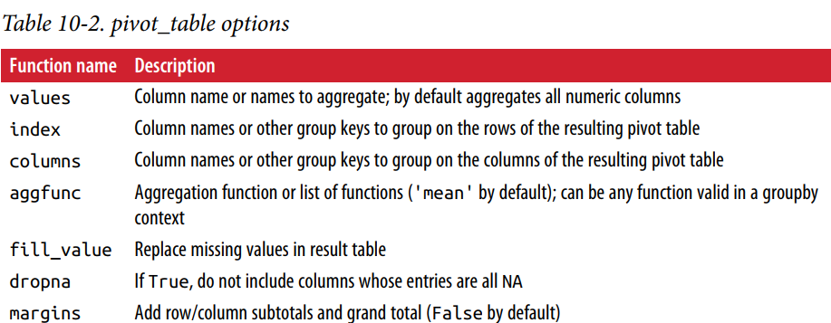

```python
tips = pd.read_csv('examples/tips.csv')
tips['tip_pct'] = tips['tip'] / tips['total_bill']
tips.head()
tips.pivot_table(index=['day', 'smoker'])
```

|  | total_bill | tip | smoker | day | time | size | tip_pct |
| --- | --- | --- | --- | --- | --- | --- | --- |
| 0 | 16.99 | 1.01 | No | Sun | Dinner | 2 | 0.059447 |
| 1 | 10.34 | 1.66 | No | Sun | Dinner | 3 | 0.160542 |
| 2 | 21.01 | 3.50 | No | Sun | Dinner | 3 | 0.166587 |
| 3 | 23.68 | 3.31 | No | Sun | Dinner | 2 | 0.139780 |
| 4 | 24.59 | 3.61 | No | Sun | Dinner | 4 | 0.146808 |

| day | smoker | size | tip | tip_pct | total_bill |
| --- | --- | --- | --- | --- | --- |
| Fri | No | 2.250000 | 2.812500 | 0.151650 | 18.420000 |
|  | Yes | 2.066667 | 2.714000 | 0.174783 | 16.813333 |
| Sat | No | 2.555556 | 3.102889 | 0.158048 | 19.661778 |
|  | Yes | 2.476190 | 2.875476 | 0.147906 | 21.276667 |
| Sun | No | 2.929825 | 3.167895 | 0.160113 | 20.506667 |
|  | Yes | 2.578947 | 3.516842 | 0.187250 | 24.120000 |
| Thur | No | 2.488889 | 2.673778 | 0.160298 | 17.113111 |
|  | Yes | 2.352941 | 3.030000 | 0.163863 | 19.190588 |

```python
tips.pivot_table(['tip_pct', 'size'], index=['time', 'day'],
                 columns='smoker')
```

| time | smoker day | size No | size Yes | tip_pct No | tip_pct Yes |
| --- | --- | --- | --- | --- | --- |
| Dinner | Fri | 2.000000 | 2.222222 | 0.139622 | 0.165347 |
|  | Sat | 2.555556 | 2.476190 | 0.158048 | 0.147906 |
|  | Sun | 2.929825 | 2.578947 | 0.160113 | 0.187250 |
|  | Thur | 2.000000 | NaN | 0.159744 | NaN |
| Lunch | Fri | 3.000000 | 1.833333 | 0.187735 | 0.188937 |
|  | Thur | 2.500000 | 2.352941 | 0.160311 | 0.163863 |

```python
tips.pivot_table(['tip_pct', 'size'], index=['time', 'day'],
                 columns='smoker', margins=True)
```

| time | smoker day | size No | size Yes | size All | tip_pct No | tip_pct Yes | tip_pct All |
| --- | --- | --- | --- | --- | --- | --- | --- |
| Dinner | Fri | 2.000000 | 2.222222 | 2.166667 | 0.139622 | 0.165347 | 0.158916 |
|  | Sat | 2.555556 | 2.476190 | 2.517241 | 0.158048 | 0.147906 | 0.153152 |
|  | Sun | 2.929825 | 2.578947 | 2.842105 | 0.160113 | 0.187250 | 0.166897 |
|  | Thur | 2.000000 | NaN | 2.000000 | 0.159744 | NaN | 0.159744 |
| Lunch | Fri | 3.000000 | 1.833333 | 2.000000 | 0.187735 | 0.188937 | 0.188765 |
|  | Thur | 2.500000 | 2.352941 | 2.459016 | 0.160311 | 0.163863 | 0.161301 |
| All |  | 2.668874 | 2.408602 | 2.569672 | 0.159328 | 0.163196 | 0.160803 |

```python
tips.pivot_table('tip_pct', index=['time', 'smoker'], columns='day',
                 aggfunc=len, margins=True)
tips.pivot_table('tip_pct', index=['time', 'smoker'],
                 columns='day', aggfunc='count', fill_value=0,margins=True)
```

| time | day smoker | Fri | Sat | Sun | Thur | All |
| --- | --- | --- | --- | --- | --- | --- |
| Dinner | No | 3.0 | 45.0 | 57.0 | 1.0 | 106.0 |
|  | Yes | 9.0 | 42.0 | 19.0 | NaN | 70.0 |
| Lunch | No | 1.0 | NaN | NaN | 44.0 | 45.0 |
|  | Yes | 6.0 | NaN | NaN | 17.0 | 23.0 |
| All |  | 19.0 | 87.0 | 76.0 | 62.0 | 244.0 |

| time | day smoker | Fri | Sat | Sun | Thur | All |
| --- | --- | --- | --- | --- | --- | --- |
| Dinner | No | 3 | 45 | 57 | 1 | 106 |
|  | Yes | 9 | 42 | 19 | 0 | 70 |
| Lunch | No | 1 | 0 | 0 | 44 | 45 |
|  | Yes | 6 | 0 | 0 | 17 | 23 |
| All |  | 19 | 87 | 76 | 62 | 244 |

```python
pd.crosstab(tips['time'],tips['smoker'],dropna=False)
pd.crosstab(tips['time'],tips['smoker'],margins=True)
pd.crosstab(tips['time'],tips['smoker'],margins=True,normalize=True)
pd.crosstab(index=tips['time'],columns=tips['smoker'],aggfunc='mean',values=tips['tip'])
```

| smoker time | No | Yes |
| --- | --- | --- |
| Dinner | 106 | 70 |
| Lunch | 45 | 23 |

| smoker time | No | Yes | All |
| --- | --- | --- | --- |
| Dinner | 106 | 70 | 176 |
| Lunch | 45 | 23 | 68 |
| All | 151 | 93 | 244 |

| smoker time | No | Yes | All |
| --- | --- | --- | --- |
| Dinner | 0.434426 | 0.286885 | 0.721311 |
| Lunch | 0.184426 | 0.094262 | 0.278689 |
| All | 0.618852 | 0.381148 | 1.000000 |

| smoker time | No | Yes |
| --- | --- | --- |
| Dinner | 3.126887 | 3.066000 |
| Lunch | 2.673778 | 2.834348 |

# 时间序列数据

> 日期基础

> 时序基础

> timestamp

> 时区处理

> periods

> resampling 时序groupby

> moving window滚动窗格

## 日期和时间数据的基础

- datetime
  - datetime.datetime
  - datetime.timedelta
  - datetime.time
  - datetime.date
  - datetime.tzinfo
- str或者strftime
  - strftime定制时间的格式
- strptime 将字符串转化为时间
  - 需要指定字符串时间的形式，比较麻烦
- from dateutil.parser import parse
  - 直接输入时间字符串即可，基本可以自动化识别时间
- pd.to_datetime()可以把字符串转化成为时间index用来给dataframe指定index

### datetime

```python
from datetime import datetime
now = datetime.now()
now
```

```
datetime.datetime(2020, 2, 5, 9, 51, 25, 605915)
```

```python
now.year, now.month, now.day, now.hour, now.second, now.microsecond
```

```
(2020, 2, 5, 9, 25, 605915)
```

```python
delta = datetime(2011, 1, 7) - datetime(2008, 6, 24, 8, 15)
delta
```

```
datetime.timedelta(days=926, seconds=56700)
```

```python
delta.days, delta.seconds,delta.total_seconds()
```

```
(926, 56700, 80063100.0)
```

```python
from datetime import timedelta
start = datetime(2011,1,7)
start + timedelta(12)
```

```
datetime.datetime(2011, 1, 19, 0, 0)
```

### string and datetime

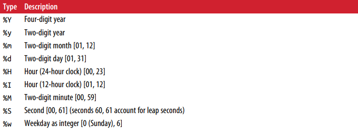

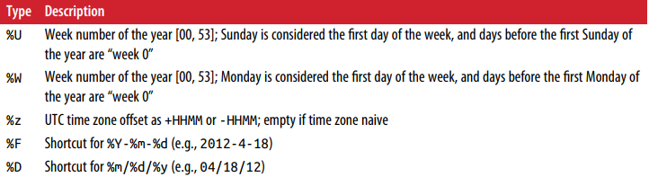

```python
stamp = datetime(2011, 1, 3)
str(stamp)
stamp.strftime('%Y-%m-%d')
```

```
'2011-01-03 00:00:00'
```

```
'2011-01-03'
```

```python
value = '2011-01-03'
datetime.strptime(value, '%Y-%m-%d')
```

```
datetime.datetime(2011, 1, 3, 0, 0)
```

```python
datestrs = ['7/6/2011', '8/6/2011']
[datetime.strptime(x, '%m/%d/%Y') for x in datestrs]
```

```
[datetime.datetime(2011, 7, 6, 0, 0), datetime.datetime(2011, 8, 6, 0, 0)]
```

```python
from dateutil.parser import parse
parse('2011-01-03')
parse('Jan 31, 1997 10:45 PM')
```

```
datetime.datetime(2011, 1, 3, 0, 0)
```

```
datetime.datetime(1997, 1, 31, 22, 45)
```

```python
'''可能混淆的地方，指明即可'''
parse('6/12/2011', dayfirst=True)
```

```
'可能混淆的地方，指明即可'
```

```
datetime.datetime(2011, 12, 6, 0, 0)
```

```python
datestrs = ['2011-07-06 12:00:00', '2011-08-06 00:00:00']
pd.to_datetime(datestrs)
```

```
DatetimeIndex(['2011-07-06 12:00:00', '2011-08-06 00:00:00'], dtype='datetime64[ns]', freq=None)
```

## 时序基础

1. index and slicing
   - 使用时间型数据作为index
     - index[0]中的元素的类型是timestamp数据
     - 可以通过年份或者年月来片段索引data['2011'],data['2011-05']
   - pd.date_range('start','end',period=100)
   - pd.truncate(before=,after=,axis=)切片方法；和loc类似，传入index名称，不过包含端点
2. 重复的索引
3. daterange
   - date_range()创建时间范围，normalize=True设定来表示标准化到每天的0点0分
   - data.shift()
     - period=1,指定数据进行滑动
     - freq='代码'指定日期index进行滑动
   - using offsets:pandas.tseries.offsets库中的函数
     - 可以使用函数修改时间，同时还可以用来作为分组index

### index and slicing

```python
from datetime import datetime
dates = [datetime(2011, 1, 2), datetime(2011, 1, 5),
         datetime(2011, 1, 7), datetime(2011, 1, 8),
         datetime(2011, 1, 10), datetime(2011, 1, 12)]
ts = pd.Series(np.random.randn(6), index=dates)
ts
ts.index
```

```
2011-01-02   -1.282992
2011-01-05    1.781482
2011-01-07   -0.967415
2011-01-08    0.987454
2011-01-10   -0.300029
2011-01-12   -0.666170
dtype: float64
```

```
DatetimeIndex(['2011-01-02', '2011-01-05', '2011-01-07', '2011-01-08',
               '2011-01-10', '2011-01-12'],
              dtype='datetime64[ns]', freq=None)
```

```python
ts.index.dtype #datetime64——M8
ts.index[0]
```

```
dtype('<M8[ns]')
```

```
Timestamp('2011-01-02 00:00:00')
```

```python
ts['1/10/2011']
ts['20110110']
```

```
-0.30002898896634
```

```
-0.30002898896634
```

```python
'''slicing'''
ts[datetime(2011, 1, 7):]
```

```
'slicing'
```

```
2011-01-07   -0.967415
2011-01-08    0.987454
2011-01-10   -0.300029
2011-01-12   -0.666170
dtype: float64
```

```python
'''与loc类似，不过包含端点'''
ts.truncate(after='1/10/2011')
```

```
'与loc类似，不过包含端点'
```

```
2011-01-02   -1.282992
2011-01-05    1.781482
2011-01-07   -0.967415
2011-01-08    0.987454
2011-01-10   -0.300029
dtype: float64
```

```python
longer_ts = pd.Series(np.random.randn(1000),
                      index=pd.date_range('1/1/2000', periods=1000))
longer_ts.tail()
```

```
2002-09-22   -0.366514
2002-09-23   -0.696114
2002-09-24   -0.942765
2002-09-25    0.184443
2002-09-26    2.303588
Freq: D, dtype: float64
```

```python
longer_ts['2000']
```

```
2000-01-01    0.275506
2000-01-02    0.063391
2000-01-03    0.783432
2000-01-04   -1.835053
2000-01-05    2.149333
                ...
2000-12-27    1.059450
2000-12-28    1.359277
2000-12-29    1.063117
2000-12-30    0.441530
2000-12-31   -1.125662
Freq: D, Length: 366, dtype: float64
```

```python
longer_ts['2000-03'].head()
```

```
2000-03-01    0.375651
2000-03-02   -1.222853
2000-03-03    0.117659
2000-03-04   -1.804031
2000-03-05    0.887765
Freq: D, dtype: float64
```

```python
dates = pd.date_range('1/1/2000', periods=100, freq='W-WED')
long_df = pd.DataFrame(np.random.randn(100, 4),
                       index=dates,
                       columns=['Colorado', 'Texas',
                                'New York', 'Ohio'])
long_df.head()
long_df.loc['2000-3']
```

|  | Colorado | Texas | New York | Ohio |
| --- | --- | --- | --- | --- |
| 2000-01-05 | -0.745713 | -0.505366 | 0.072575 | -0.725718 |
| 2000-01-12 | -0.131374 | -0.807545 | -0.261234 | -0.296890 |
| 2000-01-19 | 0.779076 | -0.591635 | -0.227673 | 1.051236 |
| 2000-01-26 | -1.000583 | 0.104625 | 0.709608 | -1.105653 |
| 2000-02-02 | -0.780142 | 0.722816 | 0.683753 | 0.226420 |

|  | Colorado | Texas | New York | Ohio |
| --- | --- | --- | --- | --- |
| 2000-03-01 | -0.621425 | -0.744568 | 0.581548 | -0.984859 |
| 2000-03-08 | 1.413539 | 0.440507 | 1.988377 | 0.661583 |
| 2000-03-15 | 1.326677 | 2.296795 | 0.188135 | 0.679581 |
| 2000-03-22 | -0.862878 | 2.035263 | -0.372322 | 0.704847 |
| 2000-03-29 | -0.530940 | -1.006286 | 1.233574 | 0.877706 |

### duplicate indices

```python
dates = pd.DatetimeIndex(['1/1/2000', '1/2/2000', '1/2/2000',
                          '1/2/2000', '1/3/2000'])
dup_ts = pd.Series(np.arange(5), index=dates)
dup_ts
```

```
2000-01-01    0
2000-01-02    1
2000-01-02    2
2000-01-02    3
2000-01-03    4
dtype: int32
```

```python
dup_ts.index.is_unique
dup_ts['1/2/2000']
dup_ts['2000-01-01']
```

```
False
```

```
2000-01-02    1
2000-01-02    2
2000-01-02    3
dtype: int32
```

```
0
```

```python
grouped = dup_ts.groupby(dup_ts.index)
grouped.mean()
grouped.count()
```

```
2000-01-01    0
2000-01-02    2
2000-01-03    4
dtype: int32
```

```
2000-01-01    1
2000-01-02    3
2000-01-03    1
dtype: int64
```

## 范围时间（date_range），频率，转换

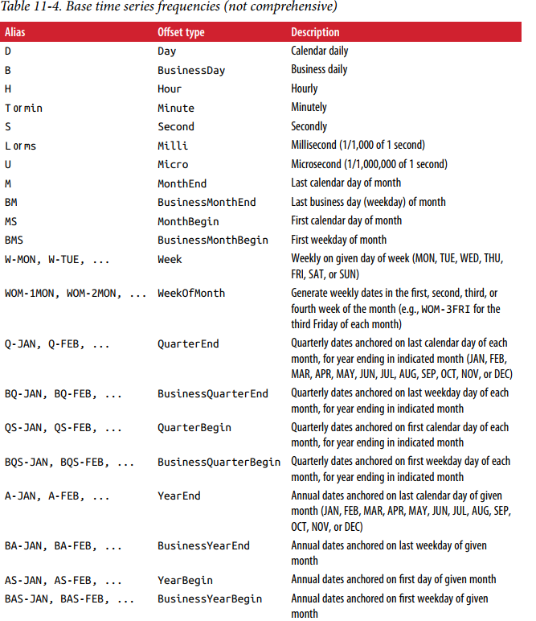

### pd.date_range()

```python
pd.date_range(start='2012-04-01', periods=20)
pd.date_range('2000-01-01', '2000-12-01', freq='BM')
```

```
DatetimeIndex(['2012-04-01', '2012-04-02', '2012-04-03', '2012-04-04',
               '2012-04-05', '2012-04-06', '2012-04-07', '2012-04-08',
               '2012-04-09', '2012-04-10', '2012-04-11', '2012-04-12',
               '2012-04-13', '2012-04-14', '2012-04-15', '2012-04-16',
               '2012-04-17', '2012-04-18', '2012-04-19', '2012-04-20'],
              dtype='datetime64[ns]', freq='D')
```

```
DatetimeIndex(['2000-01-31', '2000-02-29', '2000-03-31', '2000-04-28',
               '2000-05-31', '2000-06-30', '2000-07-31', '2000-08-31',
               '2000-09-29', '2000-10-31', '2000-11-30'],
              dtype='datetime64[ns]', freq='BM')
```

```python
pd.date_range('2012-05-02 12:56:31', periods=5, normalize=True)
```

```
DatetimeIndex(['2012-05-02', '2012-05-03', '2012-05-04', '2012-05-05',
               '2012-05-06'],
              dtype='datetime64[ns]', freq='D')
```

```python
pd.date_range('2000-01-01', periods=10, freq='1h30min')
```

```
DatetimeIndex(['2000-01-01 00:00:00', '2000-01-01 01:30:00',
               '2000-01-01 03:00:00', '2000-01-01 04:30:00',
               '2000-01-01 06:00:00', '2000-01-01 07:30:00',
               '2000-01-01 09:00:00', '2000-01-01 10:30:00',
               '2000-01-01 12:00:00', '2000-01-01 13:30:00'],
              dtype='datetime64[ns]', freq='90T')
```

```python
'''WOM——week of month,第三个星期五'''
pd.date_range('2012-01-01', '2012-09-01', freq='WOM-3FRI')
```

```
'WOM——week of month,第三个星期五'
```

```
DatetimeIndex(['2012-01-20', '2012-02-17', '2012-03-16', '2012-04-20',
               '2012-05-18', '2012-06-15', '2012-07-20', '2012-08-17'],
              dtype='datetime64[ns]', freq='WOM-3FRI')
```

### data.shift()

```python
ts = pd.Series(np.arange(1,5),
               index=pd.date_range('1/1/2000', periods=4, freq='M'))
ts
ts.shift(periods=2)
ts.shift(periods=-2) #lagging or leading
```

```
2000-01-31    1
2000-02-29    2
2000-03-31    3
2000-04-30    4
Freq: M, dtype: int32
```

```
2000-01-31    NaN
2000-02-29    NaN
2000-03-31    1.0
2000-04-30    2.0
Freq: M, dtype: float64
```

```
2000-01-31    3.0
2000-02-29    4.0
2000-03-31    NaN
2000-04-30    NaN
Freq: M, dtype: float64
```

```python
ts.shift(periods=2,freq='M') #改变index不改变数据
ts.shift(3, freq='D')
ts.shift(1, freq='90T')
```

```
2000-03-31    1
2000-04-30    2
2000-05-31    3
2000-06-30    4
Freq: M, dtype: int32
```

```
2000-02-03    1
2000-03-03    2
2000-04-03    3
2000-05-03    4
dtype: int32
```

```
2000-01-31 01:30:00    1
2000-02-29 01:30:00    2
2000-03-31 01:30:00    3
2000-04-30 01:30:00    4
Freq: M, dtype: int32
```

```python
'''可以用来计算变化率，不过现在已经有了pct_change()'''
ts / ts.shift(1) - 1
ts.pct_change(1)
```

```
'可以用来计算变化率，不过现在已经有了pct_change()'
```

```
2000-01-31         NaN
2000-02-29    1.000000
2000-03-31    0.500000
2000-04-30    0.333333
Freq: M, dtype: float64
```

```
2000-01-31         NaN
2000-02-29    1.000000
2000-03-31    0.500000
2000-04-30    0.333333
Freq: M, dtype: float64
```

### date offset：pandas.tseries.offsets

```python
import pandas.tseries.offsets as off
```

```python
now = datetime(2011, 11, 17)
now + off.Day(3)
now + off.MonthEnd(2)
```

```
Timestamp('2011-11-20 00:00:00')
```

```
Timestamp('2011-12-31 00:00:00')
```

```python
ts = pd.Series(np.random.randn(20),
               index=pd.date_range('1/15/2000', periods=20, freq='4d'))
ts
```

```
2000-01-15    0.136219
2000-01-19   -0.030505
2000-01-23    0.602373
2000-01-27   -1.562216
2000-01-31   -0.833680
2000-02-04    0.987070
2000-02-08    0.710294
2000-02-12    0.013715
2000-02-16   -0.017071
2000-02-20    0.642162
2000-02-24   -0.079624
2000-02-28    0.015459
2000-03-03   -1.008953
2000-03-07   -0.161975
2000-03-11   -2.366292
2000-03-15    0.128630
2000-03-19   -0.947376
2000-03-23    0.731965
2000-03-27   -0.275480
2000-03-31    0.228750
Freq: 4D, dtype: float64
```

```python
'''可以用作分组函数进行分组，用途广泛'''
ts.groupby(off.MonthBegin().rollback).count()
ts.groupby(off.MonthBegin().rollback).mean()
```

```
'可以用作分组函数进行分组，用途广泛'
```

```
2000-01-01    5
2000-02-01    7
2000-03-01    8
dtype: int64
```

```
2000-01-01   -0.337562
2000-02-01    0.324572
2000-03-01   -0.458841
dtype: float64
```

## 时区的处理

1. UTC格林维尔世界标准时间
   - pytz包可以处理时区问题
   - data.tz_localize('UTC')时区代码，指定当前时间是哪个时区的时间
   - data.tz_convert('China')转换时区显示：-2012-03-09 04:30:00-05:00-后面的-5:00表示比标准时间晚5个小时
   - 每年3月11日，纽约开始实行日光节约时间，所以时间会播快一个小时，使得和UTC的时间差少一个小时
2. index涉及时区时无需担心，因为会转化成UTC时间进行统一计算和匹配

```python
import pytz
len(pytz.common_timezones)
```

```
440
```

```python
rng = pd.date_range('3/9/2012 9:30', periods=6, freq='D')
ts = pd.Series(np.random.randn(len(rng)), index=rng)
ts
```

```
2012-03-09 09:30:00    0.110593
2012-03-10 09:30:00    2.173037
2012-03-11 09:30:00    0.108740
2012-03-12 09:30:00   -0.233382
2012-03-13 09:30:00    1.957020
2012-03-14 09:30:00   -0.303869
Freq: D, dtype: float64
```

```python
'''默认不加时区'''
print(ts.index.tz)
```

```
None
```

```python
#ts.tz_localize()
ts_utc = ts.tz_localize('UTC')
ts_utc
ts_utc.index.dtype
```

```
2012-03-09 09:30:00+00:00    0.110593
2012-03-10 09:30:00+00:00    2.173037
2012-03-11 09:30:00+00:00    0.108740
2012-03-12 09:30:00+00:00   -0.233382
2012-03-13 09:30:00+00:00    1.957020
2012-03-14 09:30:00+00:00   -0.303869
Freq: D, dtype: float64
```

```
datetime64[ns, UTC]
```

```python
ts_utc.tz_convert('America/New_York')
```

```
2012-03-09 04:30:00-05:00    0.110593
2012-03-10 04:30:00-05:00    2.173037
2012-03-11 05:30:00-04:00    0.108740
2012-03-12 05:30:00-04:00   -0.233382
2012-03-13 05:30:00-04:00    1.957020
2012-03-14 05:30:00-04:00   -0.303869
Freq: D, dtype: float64
```

```python
'''指定当前时间是纽约时间同时转化为UTC时间'''
ts_eastern = ts.tz_localize('America/New_York')
ts_eastern.tz_convert('UTC')
```

```
'指定当前时间是纽约时间同时转化为UTC时间'
```

```
2012-03-09 14:30:00+00:00    0.110593
2012-03-10 14:30:00+00:00    2.173037
2012-03-11 13:30:00+00:00    0.108740
2012-03-12 13:30:00+00:00   -0.233382
2012-03-13 13:30:00+00:00    1.957020
2012-03-14 13:30:00+00:00   -0.303869
Freq: D, dtype: float64
```

```python
stamp = pd.Timestamp('2011-03-12 04:00')
stamp_utc = stamp.tz_localize('utc')
stamp_utc.tz_convert('America/New_York')
```

```
Timestamp('2011-03-11 23:00:00-0500', tz='America/New_York')
```

```python
stamp_moscow = pd.Timestamp('2011-03-12 04:00', tz='Europe/Moscow')
stamp_moscow
```

```
Timestamp('2011-03-12 04:00:00+0300', tz='Europe/Moscow')
```

```python
stamp.value #从1970年1月1日开始到所示日期经过了多少ns（10-9秒）
##不随时区的转化而改变
stamp_utc.tz_convert('America/New_York').value
```

```
1299902400000000000
```

```
1299902400000000000
```

```python
'''2019-3-10凌晨2点会实行日光节约时间，所以时钟会快一个小时，这里时间小Trick'''
stamp = pd.Timestamp('2019-03-10 01:30', tz='US/Eastern')
stamp
stamp + off.Hour()
```

[output not shown]

```
Timestamp('2019-03-10 01:30:00-0500', tz='US/Eastern')
```

```
Timestamp('2019-03-10 03:30:00-0400', tz='US/Eastern')
```

```python
'''2019-11-3凌晨2点会结束日光节约时间，所以时钟会慢一个小时，这里时间小Trick'''
stamp_end = pd.Timestamp('2019-11-03 00:30', tz='US/Eastern')
stamp_end
stamp_end + off.Hour(2)
```

```
Timestamp('2019-11-03 00:30:00-0400', tz='US/Eastern')
```

```
Timestamp('2019-11-03 01:30:00-0500', tz='US/Eastern')
```

```python
rng = pd.date_range('3/7/2012 9:30', periods=10, freq='B') #工作日时间
ts = pd.Series(np.random.randn(len(rng)), index=rng)
ts
```

```
2012-03-07 09:30:00    1.091455
2012-03-08 09:30:00   -0.654448
2012-03-09 09:30:00    2.271265
2012-03-12 09:30:00    1.937885
2012-03-13 09:30:00   -0.227701
2012-03-14 09:30:00   -0.255222
2012-03-15 09:30:00   -1.516455
2012-03-16 09:30:00   -1.376540
2012-03-19 09:30:00   -1.862883
2012-03-20 09:30:00   -0.228911
Freq: B, dtype: float64
```

```python
'''index涉及时区时无需担心，因为会转化成UTC时间进行统一计算和匹配'''
ts1 = ts[:7].tz_localize('Europe/London')
ts2 = ts1[2:].tz_convert('Europe/Moscow')
result = ts1 + ts2
result.index
result
```

```
'index涉及时区时无需担心，因为会转化成UTC时间进行统一计算和匹配'
```

```
DatetimeIndex(['2012-03-07 09:30:00+00:00', '2012-03-08 09:30:00+00:00',
               '2012-03-09 09:30:00+00:00', '2012-03-12 09:30:00+00:00',
               '2012-03-13 09:30:00+00:00', '2012-03-14 09:30:00+00:00',
               '2012-03-15 09:30:00+00:00'],
              dtype='datetime64[ns, UTC]', freq='B')
```

```
2012-03-07 09:30:00+00:00         NaN
2012-03-08 09:30:00+00:00         NaN
2012-03-09 09:30:00+00:00    4.542529
2012-03-12 09:30:00+00:00    3.875770
2012-03-13 09:30:00+00:00   -0.455401
2012-03-14 09:30:00+00:00   -0.510444
2012-03-15 09:30:00+00:00   -3.032911
Freq: B, dtype: float64
```

## Periods对象

1. pandas中时间分为2类
   - Timestamp特定的时间点——date_range
   - Period一个时间段——period_range
2. 频率转换
   - pd.Period().asfreq()
     - 低频转高频，需要指定how='endstart'
     - 高频转低频，根据目标频率自动判断属于哪个频段，然后完成转换
   - data.to_timestamp()
   - data.to_period() 互相转化

```python
p = pd.Period(2007, freq='A-DEC')
p
p+5
pd.Period('2014', freq='A-DEC') - p
```

```
Period('2007', 'A-DEC')
```

```
Period('2012', 'A-DEC')
```

```
<7 * YearEnds: month=12>
```

```python
rng = pd.period_range('2000-01-01', '2000-06-30', freq='M')
rng
pd.Series(np.random.rand(6), index=rng)
```

```
PeriodIndex(['2000-01', '2000-02', '2000-03', '2000-04', '2000-05', '2000-06'], dtype='period[M]', freq='M')
```

```
2000-01    0.251951
2000-02    0.243425
2000-03    0.187019
2000-04    0.882392
2000-05    0.064881
2000-06    0.215169
Freq: M, dtype: float64
```

```python
values = ['2001Q3', '2002Q2', '2003Q1']
index = pd.PeriodIndex(values, freq='Q-DEC')
index
```

```
PeriodIndex(['2001Q3', '2002Q2', '2003Q1'], dtype='period[Q-DEC]', freq='Q-DEC')
```

### frenquency convertion

#### 从低频到高频

```python
p = pd.Period('2007', freq='A-JUN')
p
p.asfreq('M',how='start')
p.asfreq('M',how='end')
```

```
Period('2007', 'A-JUN')
```

```
Period('2006-07', 'M')
```

```
Period('2007-06', 'M')
```

#### 从高频到低频

```python
p = pd.Period('Aug-2007', 'M')
p.asfreq('A-JUN')
p.asfreq('A-SEP')
```

```
Period('2008', 'A-JUN')
```

```
Period('2007', 'A-SEP')
```

```python
rng = pd.period_range('2006', '2009', freq='A-DEC')
ts = pd.Series(np.random.randn(len(rng)), index=rng)
ts
```

```
2006    0.527254
2007    2.764131
2008   -0.651996
2009   -1.187652
Freq: A-DEC, dtype: float64
```

```python
ts.asfreq('M', how='start')
ts.asfreq('B', how='end')
```

```
2006-01    0.527254
2007-01    2.764131
2008-01   -0.651996
2009-01   -1.187652
Freq: M, dtype: float64
```

```
2006-12-29    0.527254
2007-12-31    2.764131
2008-12-31   -0.651996
2009-12-31   -1.187652
Freq: B, dtype: float64
```

#### 季度period

```python
'''2012指名了哪一年，后面的freq指定了截至的时间'''
p = pd.Period('2012Q4', freq='Q-JAN')
p
p.asfreq('D', 'start')
p.asfreq('D', 'end')
```

```
Period('2012Q4', 'Q-JAN')
```

```
Period('2011-11-01', 'D')
```

```
Period('2012-01-31', 'D')
```

```python
'''获取本季度倒数第二个工作日下午4点的时间戳'''
p4pm = (p.asfreq('B', 'e') - 1).asfreq('T', 's') + 16 * 60
p4pm
p4pm.to_timestamp()
```

```
'获取本季度倒数第二个工作日下午4点的时间戳'
```

```
Period('2012-01-30 16:00', 'T')
```

```
Timestamp('2012-01-30 16:00:00')
```

```python
rng = pd.period_range('2011Q3', '2012Q4', freq='Q-JAN')
ts = pd.Series(np.arange(len(rng)), index=rng)
ts
```

```
2011Q3    0
2011Q4    1
2012Q1    2
2012Q2    3
2012Q3    4
2012Q4    5
Freq: Q-JAN, dtype: int32
```

```python
new_rng = (rng.asfreq('B', 'e') - 1).asfreq('T', 's') + 16 * 60
ts.index = new_rng.to_timestamp()
ts
```

```
2010-10-28 16:00:00    0
2011-01-28 16:00:00    1
2011-04-28 16:00:00    2
2011-07-28 16:00:00    3
2011-10-28 16:00:00    4
2012-01-30 16:00:00    5
dtype: int32
```

#### timestamp to periods

```python
'''to_period默认和timestamp一样的频率'''
rng = pd.date_range('2000-01-01', periods=3, freq='M')
ts = pd.Series(np.random.randn(3), index=rng)
ts
pts = ts.to_period()
pts
```

```
'to_period默认和timestamp一样的频率'
```

```
2000-01-31   -1.603618
2000-02-29    0.075038
2000-03-31   -0.867816
Freq: M, dtype: float64
```

```
2000-01   -1.603618
2000-02    0.075038
2000-03   -0.867816
Freq: M, dtype: float64
```

```python
'''指定转换的频率'''
rng = pd.date_range('1/29/2000', periods=6, freq='D')
ts2 = pd.Series(np.random.randn(6), index=rng)
ts2
ts2.to_period('M')
```

```
'指定转换的频率'
```

```
2000-01-29    0.090785
2000-01-30   -1.063192
2000-01-31   -1.160462
2000-02-01    0.687615
2000-02-02   -0.182515
2000-02-03   -0.095295
Freq: D, dtype: float64
```

```
2000-01    0.090785
2000-01   -1.063192
2000-01   -1.160462
2000-02    0.687615
2000-02   -0.182515
2000-02   -0.095295
Freq: M, dtype: float64
```

```python
data = pd.read_csv('examples/macrodata.csv')
data.head()
index = pd.PeriodIndex(year=data.year, quarter=data.quarter,
                       freq='Q-DEC') #可以这样指定
data.index = index
data.head()
```

|  | year | quarter | realgdp | realcons | realinv | realgovt | realdpi | cpi | m1 | tbilrate | unemp | pop | infl | realint |
| --- | --- | --- | --- | --- | --- | --- | --- | --- | --- | --- | --- | --- | --- | --- |
| 0 | 1959.0 | 1.0 | 2710.349 | 1707.4 | 286.898 | 470.045 | 1886.9 | 28.98 | 139.7 | 2.82 | 5.8 | 177.146 | 0.00 | 0.00 |
| 1 | 1959.0 | 2.0 | 2778.801 | 1733.7 | 310.859 | 481.301 | 1919.7 | 29.15 | 141.7 | 3.08 | 5.1 | 177.830 | 2.34 | 0.74 |
| 2 | 1959.0 | 3.0 | 2775.488 | 1751.8 | 289.226 | 491.260 | 1916.4 | 29.35 | 140.5 | 3.82 | 5.3 | 178.657 | 2.74 | 1.09 |
| 3 | 1959.0 | 4.0 | 2785.204 | 1753.7 | 299.356 | 484.052 | 1931.3 | 29.37 | 140.0 | 4.33 | 5.6 | 179.386 | 0.27 | 4.06 |
| 4 | 1960.0 | 1.0 | 2847.699 | 1770.5 | 331.722 | 462.199 | 1955.5 | 29.54 | 139.6 | 3.50 | 5.2 | 180.007 | 2.31 | 1.19 |

|  | year | quarter | realgdp | realcons | realinv | realgovt | realdpi | cpi | m1 | tbilrate | unemp | pop | infl | realint |
| --- | --- | --- | --- | --- | --- | --- | --- | --- | --- | --- | --- | --- | --- | --- |
| 1959Q1 | 1959.0 | 1.0 | 2710.349 | 1707.4 | 286.898 | 470.045 | 1886.9 | 28.98 | 139.7 | 2.82 | 5.8 | 177.146 | 0.00 | 0.00 |
| 1959Q2 | 1959.0 | 2.0 | 2778.801 | 1733.7 | 310.859 | 481.301 | 1919.7 | 29.15 | 141.7 | 3.08 | 5.1 | 177.830 | 2.34 | 0.74 |
| 1959Q3 | 1959.0 | 3.0 | 2775.488 | 1751.8 | 289.226 | 491.260 | 1916.4 | 29.35 | 140.5 | 3.82 | 5.3 | 178.657 | 2.74 | 1.09 |
| 1959Q4 | 1959.0 | 4.0 | 2785.204 | 1753.7 | 299.356 | 484.052 | 1931.3 | 29.37 | 140.0 | 4.33 | 5.6 | 179.386 | 0.27 | 4.06 |
| 1960Q1 | 1960.0 | 1.0 | 2847.699 | 1770.5 | 331.722 | 462.199 | 1955.5 | 29.54 | 139.6 | 3.50 | 5.2 | 180.007 | 2.31 | 1.19 |

## resampling:时序数据特殊的groupby,容易弄错，参数最好明确

1. data.resampling().方法
   1. 一个适用于股市的方法，data.resampling().ohlc()显示分组的开盘收盘，最高最低值
   2. 可以大致分为上采样和下采用
   3. downsampling：
      1. 可以把时间频率放慢，可以选择参数：closed决定左右区间那边闭合
      2. label显示左右端点的哪一个；
      3. loffset可以对端点值进行一些操作
   4. upsampling:
      1. 可以把时间频率加快。
      2. data.resampling().asfreq()能够显示出来结果
      3. data.resampling().ffill()进行向前填充缺失值
2. 以上都是timestamp的resampling方法
   1. 这里是period的resampling方法
   2. 下采样放慢区间时，closed参数好像没有用了
   3. 上采样的时候需要使用convention='start/end'方法来决定选取哪个细分区间，类似period.asfreq(how='end/start')

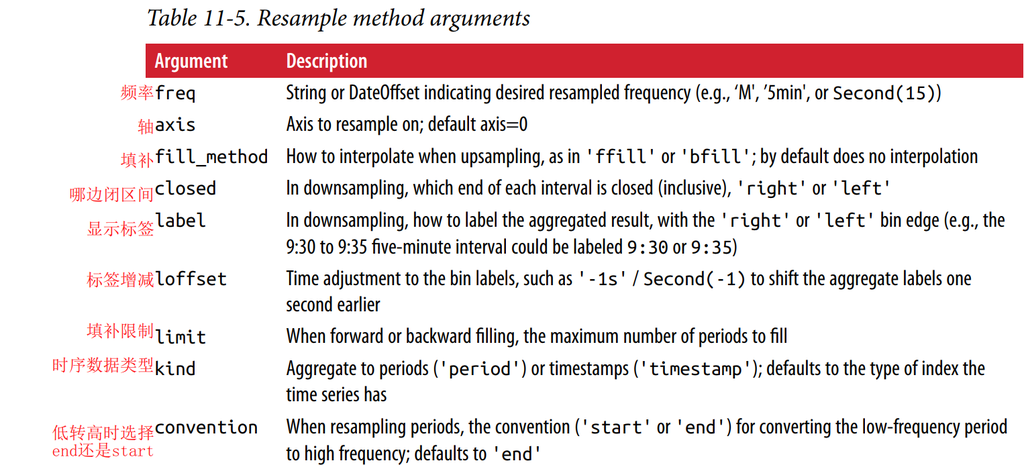

```python
rng = pd.date_range('2000-01-01', periods=100, freq='D')
ts = pd.Series(np.random.randn(len(rng)),index=rng)
ts
```

```
2000-01-01    0.369191
2000-01-02    0.194948
2000-01-03    0.219438
2000-01-04    1.144634
2000-01-05   -1.321036
                ...
2000-04-05    0.854484
2000-04-06   -1.597733
2000-04-07   -0.503601
2000-04-08   -0.862432
2000-04-09    0.742249
Freq: D, Length: 100, dtype: float64
```

```python
ts.resample('M').mean()
ts.resample('M', kind='period').mean()
```

```
2000-01-31    0.280542
2000-02-29   -0.012202
2000-03-31    0.042784
2000-04-30    0.171746
Freq: M, dtype: float64
```

```
2000-01    0.280542
2000-02   -0.012202
2000-03    0.042784
2000-04    0.171746
Freq: M, dtype: float64
```

### downsampling:把时间频率减小

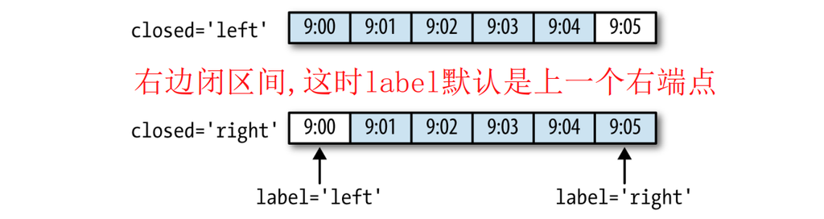

```python
rng = pd.date_range('2000-01-01', periods=12, freq='T')
ts = pd.Series(np.arange(12), index=rng)
ts
```

```
2000-01-01 00:00:00     0
2000-01-01 00:01:00     1
2000-01-01 00:02:00     2
2000-01-01 00:03:00     3
2000-01-01 00:04:00     4
2000-01-01 00:05:00     5
2000-01-01 00:06:00     6
2000-01-01 00:07:00     7
2000-01-01 00:08:00     8
2000-01-01 00:09:00     9
2000-01-01 00:10:00    10
2000-01-01 00:11:00    11
Freq: T, dtype: int32
```

```python
'''对比closed不同的区别，区间代表label就不同'''
ts.resample('5min',closed='right').sum()
ts.resample('5min',closed='left').sum()
```

```
1999-12-31 23:55:00     0
2000-01-01 00:00:00    15
2000-01-01 00:05:00    40
2000-01-01 00:10:00    11
Freq: 5T, dtype: int32
```

```
2000-01-01 00:00:00    10
2000-01-01 00:05:00    35
2000-01-01 00:10:00    21
Freq: 5T, dtype: int32
```

```python
'''右边闭区间的话，可以通过label来调整显示左端点还是右端点'''
ts.resample('5min', closed='right', label='right').sum()
```

```
'右边闭区间的话，可以通过label来调整显示左端点还是右端点'
```

```
2000-01-01 00:00:00     0
2000-01-01 00:05:00    15
2000-01-01 00:10:00    40
2000-01-01 00:15:00    11
Freq: 5T, dtype: int32
```

```python
ts.resample('5min', closed='right', label='right',loffset='1s').sum()
```

```
2000-01-01 00:00:01     0
2000-01-01 00:05:01    15
2000-01-01 00:10:01    40
2000-01-01 00:15:01    11
Freq: 5T, dtype: int32
```

```python
'''一键获取时间段内的开盘收盘，最高最低值，股票数据很好用'''
ts.resample('5min').ohlc()
```

|  | open | high | low | close |
| --- | --- | --- | --- | --- |
| 2000-01-01 00:00:00 | 0 | 4 | 0 | 4 |
| 2000-01-01 00:05:00 | 5 | 9 | 5 | 9 |
| 2000-01-01 00:10:00 | 10 | 11 | 10 | 11 |

### upsampling：把时间频率加快

```python
frame = pd.DataFrame(np.random.randn(2, 4),
                     index=pd.date_range('1/1/2000', periods=2,
                                         freq='W-WED'),
                     columns=['Colorado', 'Texas', 'New York', 'Ohio'])
frame
```

|  | Colorado | Texas | New York | Ohio |
| --- | --- | --- | --- | --- |
| 2000-01-05 | -0.145481 | -0.071591 | -1.025724 | -1.124242 |
| 2000-01-12 | -0.551533 | -0.190065 | 0.508860 | 0.765674 |

```python
frame.resample('D').asfreq()
frame.resample('D').ffill()
```

|  | Colorado | Texas | New York | Ohio |
| --- | --- | --- | --- | --- |
| 2000-01-05 | -0.145481 | -0.071591 | -1.025724 | -1.124242 |
| 2000-01-06 | NaN | NaN | NaN | NaN |
| 2000-01-07 | NaN | NaN | NaN | NaN |
| 2000-01-08 | NaN | NaN | NaN | NaN |
| 2000-01-09 | NaN | NaN | NaN | NaN |
| 2000-01-10 | NaN | NaN | NaN | NaN |
| 2000-01-11 | NaN | NaN | NaN | NaN |
| 2000-01-12 | -0.551533 | -0.190065 | 0.508860 | 0.765674 |

|  | Colorado | Texas | New York | Ohio |
| --- | --- | --- | --- | --- |
| 2000-01-05 | -0.145481 | -0.071591 | -1.025724 | -1.124242 |
| 2000-01-06 | -0.145481 | -0.071591 | -1.025724 | -1.124242 |
| 2000-01-07 | -0.145481 | -0.071591 | -1.025724 | -1.124242 |
| 2000-01-08 | -0.145481 | -0.071591 | -1.025724 | -1.124242 |
| 2000-01-09 | -0.145481 | -0.071591 | -1.025724 | -1.124242 |
| 2000-01-10 | -0.145481 | -0.071591 | -1.025724 | -1.124242 |
| 2000-01-11 | -0.145481 | -0.071591 | -1.025724 | -1.124242 |
| 2000-01-12 | -0.551533 | -0.190065 | 0.508860 | 0.765674 |

```python
frame.resample('W-THU').asfreq()
```

|  | Colorado | Texas | New York | Ohio |
| --- | --- | --- | --- | --- |
| 2000-01-06 | NaN | NaN | NaN | NaN |
| 2000-01-13 | NaN | NaN | NaN | NaN |

### resampling with periods

```python
frame = pd.DataFrame(np.random.randn(24, 4),
                     index=pd.period_range('1-2000', '12-2001',
                                           freq='M'),
                     columns=['Colorado', 'Texas', 'New York', 'Ohio'])
frame.head()
```

|  | Colorado | Texas | New York | Ohio |
| --- | --- | --- | --- | --- |
| 2000-01 | -0.040739 | -0.055095 | -2.109400 | 1.347171 |
| 2000-02 | -0.275477 | 1.135419 | -0.203348 | 0.789368 |
| 2000-03 | 0.785047 | 0.525756 | -0.153907 | 0.517354 |
| 2000-04 | -0.008100 | 0.275042 | 0.123083 | 0.107544 |
| 2000-05 | -1.687456 | 0.912086 | 0.555950 | 0.116543 |

```python
annual_frame = frame.resample('A-DEC').mean()
annual_frame
```

|  | Colorado | Texas | New York | Ohio |
| --- | --- | --- | --- | --- |
| 2000 | -0.361808 | 0.201487 | -0.262499 | 0.011570 |
| 2001 | 0.015663 | 0.344253 | -0.066858 | -0.159065 |

```python
'''上采样periods怎么采'''
annual_frame.resample('Q-DEC').ffill()
annual_frame.resample('Q-DEC',convention='end').ffill()
```

```
'上采样periods怎么采'
```

|  | Colorado | Texas | New York | Ohio |
| --- | --- | --- | --- | --- |
| 2000Q1 | -0.361808 | 0.201487 | -0.262499 | 0.011570 |
| 2000Q2 | -0.361808 | 0.201487 | -0.262499 | 0.011570 |
| 2000Q3 | -0.361808 | 0.201487 | -0.262499 | 0.011570 |
| 2000Q4 | -0.361808 | 0.201487 | -0.262499 | 0.011570 |
| 2001Q1 | 0.015663 | 0.344253 | -0.066858 | -0.159065 |
| 2001Q2 | 0.015663 | 0.344253 | -0.066858 | -0.159065 |
| 2001Q3 | 0.015663 | 0.344253 | -0.066858 | -0.159065 |
| 2001Q4 | 0.015663 | 0.344253 | -0.066858 | -0.159065 |

|  | Colorado | Texas | New York | Ohio |
| --- | --- | --- | --- | --- |
| 2000Q4 | -0.361808 | 0.201487 | -0.262499 | 0.011570 |
| 2001Q1 | -0.361808 | 0.201487 | -0.262499 | 0.011570 |
| 2001Q2 | -0.361808 | 0.201487 | -0.262499 | 0.011570 |
| 2001Q3 | -0.361808 | 0.201487 | -0.262499 | 0.011570 |
| 2001Q4 | 0.015663 | 0.344253 | -0.066858 | -0.159065 |

```python
'''something interesting，注意annual_frame的freq是A-DEC'''
annual_frame.resample('Q-MAR').ffill()
```

```
'something interesting，注意annual_frame的freq是A-DEC'
```

|  | Colorado | Texas | New York | Ohio |
| --- | --- | --- | --- | --- |
| 2000Q4 | -0.361808 | 0.201487 | -0.262499 | 0.011570 |
| 2001Q1 | -0.361808 | 0.201487 | -0.262499 | 0.011570 |
| 2001Q2 | -0.361808 | 0.201487 | -0.262499 | 0.011570 |
| 2001Q3 | -0.361808 | 0.201487 | -0.262499 | 0.011570 |
| 2001Q4 | 0.015663 | 0.344253 | -0.066858 | -0.159065 |
| 2002Q1 | 0.015663 | 0.344253 | -0.066858 | -0.159065 |
| 2002Q2 | 0.015663 | 0.344253 | -0.066858 | -0.159065 |
| 2002Q3 | 0.015663 | 0.344253 | -0.066858 | -0.159065 |

```python
'''当不成倍数的时候就可能会产生多的数据'''
annual_frame.resample('Q-JAN').ffill()
annual_frame.resample('Q-JAN',convention='end').ffill()
```

```
'当不成倍数的时候就可能会产生多的数据'
```

|  | Colorado | Texas | New York | Ohio |
| --- | --- | --- | --- | --- |
| 2000Q4 | -0.361808 | 0.201487 | -0.262499 | 0.011570 |
| 2001Q1 | -0.361808 | 0.201487 | -0.262499 | 0.011570 |
| 2001Q2 | -0.361808 | 0.201487 | -0.262499 | 0.011570 |
| 2001Q3 | -0.361808 | 0.201487 | -0.262499 | 0.011570 |
| 2001Q4 | 0.015663 | 0.344253 | -0.066858 | -0.159065 |
| 2002Q1 | 0.015663 | 0.344253 | -0.066858 | -0.159065 |
| 2002Q2 | 0.015663 | 0.344253 | -0.066858 | -0.159065 |
| 2002Q3 | 0.015663 | 0.344253 | -0.066858 | -0.159065 |
| 2002Q4 | 0.015663 | 0.344253 | -0.066858 | -0.159065 |

|  | Colorado | Texas | New York | Ohio |
| --- | --- | --- | --- | --- |
| 2001Q4 | -0.361808 | 0.201487 | -0.262499 | 0.011570 |
| 2002Q1 | -0.361808 | 0.201487 | -0.262499 | 0.011570 |
| 2002Q2 | -0.361808 | 0.201487 | -0.262499 | 0.011570 |
| 2002Q3 | -0.361808 | 0.201487 | -0.262499 | 0.011570 |
| 2002Q4 | 0.015663 | 0.344253 | -0.066858 | -0.159065 |